# **METARET**

a meta-analysis of risk elicitation tasks

# Introduction

## Slovic (1962)

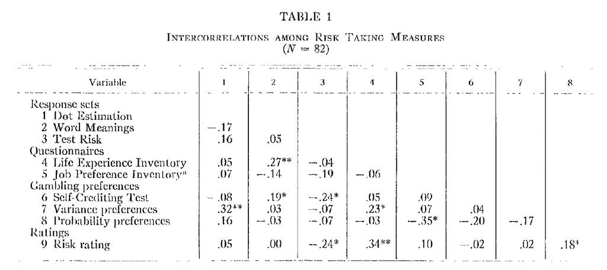

- *“…future research must carefully consider the problem of adequately **defining** and **assessing** risk taking behavior.”*

# So, how are we doing?

## Measuring risk attitudes

> A **difficult** task with **crucial** relevance
- directly *unobservable*
- *latent* construct ($\Rightarrow$ requires a theory)
- should we..
  - *infer* from real world data or from *ad-hoc* choices
  - ask or **t**ask?
  - elicit by *descrption* or by *experience*?

> and by the way, what is our **objective**?

## The state of the art: psychology

> risk loosely defined as **probability of harm**

> focus on **questionnaires** and **intuitive tasks**
- **Quests**:
  - directly ask
  - over different domains
  - tackle risk perception
- **Tasks**
  - hand in cold water
  - card/gambling tasks

> Metrics of success: **convergent validity** + **predictive validity**

## The state of the art: economics

> risk formally defined as **uncertainty over outcomes**

> focus on **decontextualized tasks** (and *questionnaires*)
- **The lottery paradigm**
  - incentives
  - risk task = choice over lotteries
  - different formats, cover stories, contexts
  - strong theoretical underpinning
  - estimation of utility functions ($\Rightarrow$ models)

> Metric of success: **internal validity** (task $\iff$ theory)

## METARET: goals

- **Part 1: state of the art**
  - a *detailed map* of elicited risk attitudes
  - an assessment of *convergent validity*
  - an assessment of *predictive validity*
- **Part 2: moving forward**
  - theoretical: what are we measuring?
  - empirical: develop a better tool

## METARET resources

- **your** data (*thanks!*)
- preregistration on [OSF](https://osf.io/h2z56/)
- transparent data collection & analysis on [gitHub](https://github.com/paolocrosetto/METARET)
- live data exploration on a [shiny app](https://paolocrosetto.shinyapps.io/METARET/)

## Contributors so far (17.321 subjects)

- Gnambs Appel and Oeberst (PONE 2015)
- Crosetto and Filippin (EXEC 2016)
- Filippin and Crosetto (ManSci 2016)
- Pedroni Frey Bruhin Dutilh Hertwig and Rieskamp (NHB 2016)
- Menkhoff and Sakha (JEconPsy 2017)
- Frey Pedroni Mata Rieskamp and Hertwig (ScAdv 2017)
- Nielsen (JEBO 2019)
- Charness Garcia Offerman and Villeval (WP 2019)
- Holzmeister and Stefan (WP 2018)
- Zhou and Hey (ExEc 2018)
- Fairley Parelman Jones and McKell Carter (JEconPsy 2018)
- Csermely Rabas (JRU 2018)

# Elicited risk attitudes

## Holt and Laury

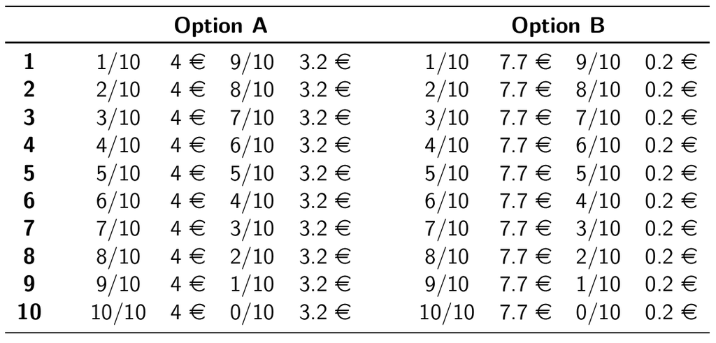

## Binswanger / Eckel and Grossmann

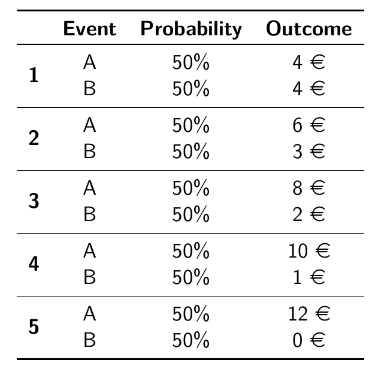

## Bomb Risk Elicitation Task

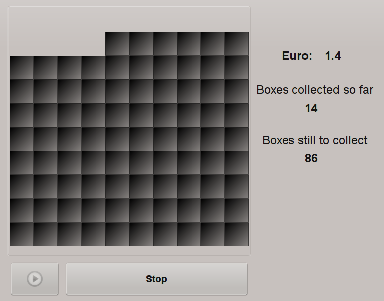

## Investment Game (Gneezy and Potters)

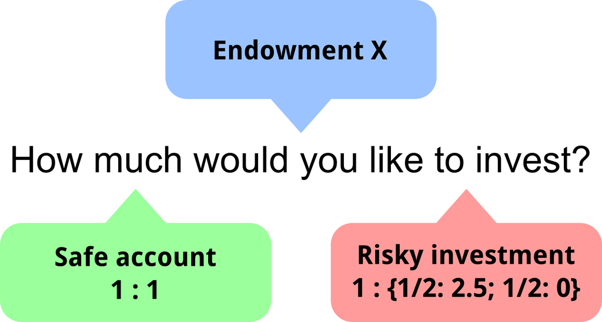

## Balloon Analog Risk Task (Lejuez et al)

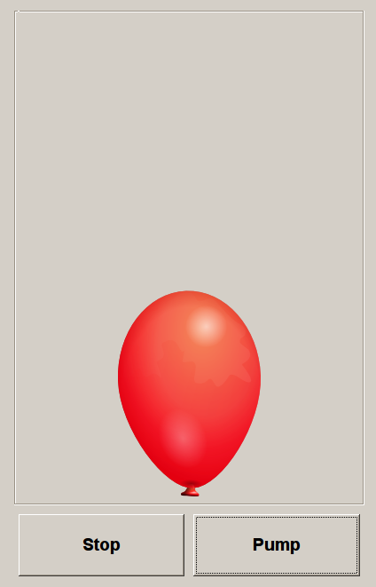

## Certainty Equivalent MPL

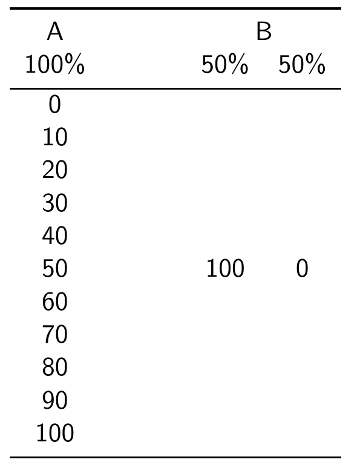

## CRRA (à la Wakker)

$u(x) = x^r$

- simple
- captures risk aversion
- makes different tasks comparable

## How big are these differences?

[figure not shown]

## Elicited attitudes: summary

- **low** consistency across tasks
- surprisingly, **low** consistency also *within* tasks
- but **heterogeneity** by task is large
- only result that holds: most people are *risk averse*

> possible explanation: between-subjects variation.

# Questionnaires

## Questionnaires: summary

- **better** consistency across samples
- a tendency to report *‘in the middle’*
- we do not really know what those number mean

# Convergent validity: **correlations** among RETs

## Convergence: more evidence

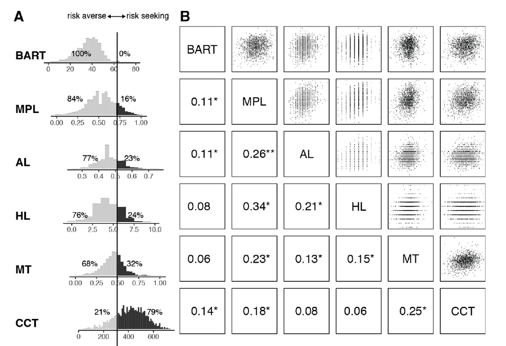

## Convergence: summary

- we replicate Slovic 1962 (!!)
- no correlation higher than .35
- when transalitng into r things get *worse*

# Predictive validity: correlation with questionnaires

## Predictive validity: more evidence

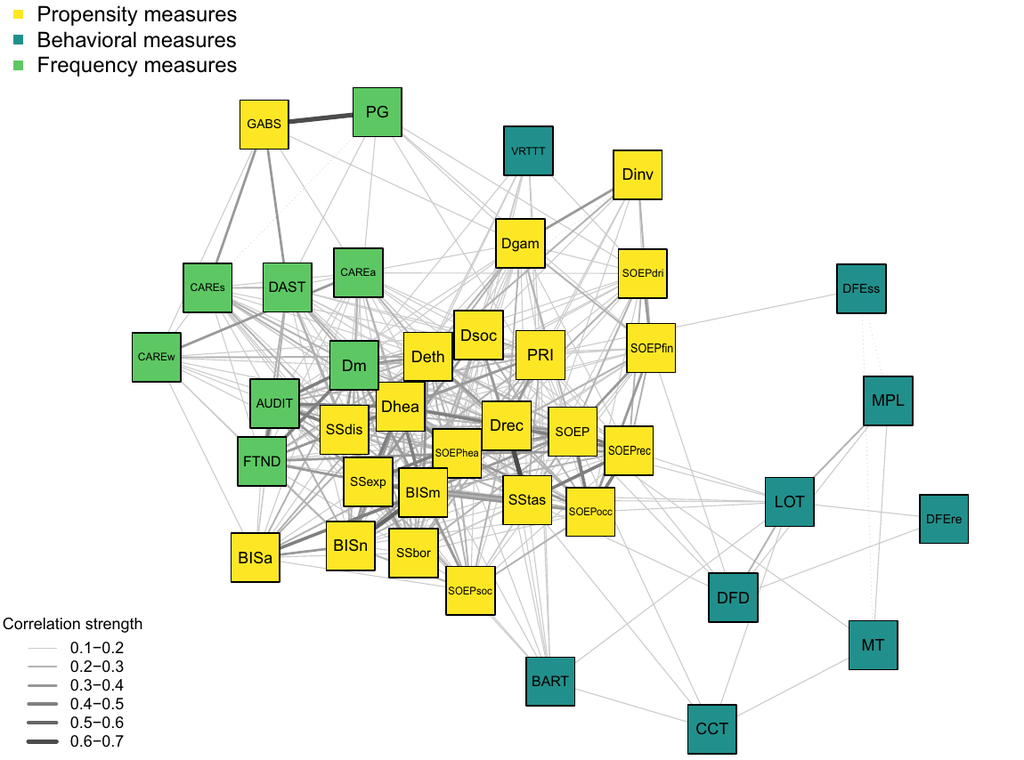

## Predictive validity: summary

- **low** correlations with questionnaires
- across questionnaires and tasks
- Beauchamp et al JRU 2016: questionnaires are rather predictive

> **we have a problem**

# Why?

## Noise

> *noisy* preference + one-shot choices $\Rightarrow$ noisy data
- cognitive limits $\Rightarrow$ limited understanding
- *if* risk preferences fuzzy $\Rightarrow$ noisy estiamte

> solution: go **fully structural**
- Hey and Orme 1994
- Harrison and coauthors (several papers)

> forget quick & dirty task, embrace complexity

> Maximum Likelihood at the **individual** level

## Risk perception

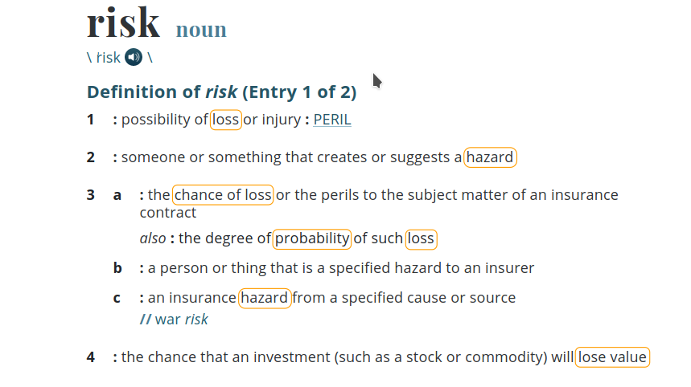

## Risk perception: a mismatch

- economists *assume* subjects share the same risk *definition*
- namely:
  - risk as a distribution of **probability** over outcomes
  - $EV$ as the average across all possible states of the world
  - risk aversion as diminishing marginal utility of money
  - subjects care about **variance**
- but subjects think of risk as *probability of a loss*
- *do subjects find our tasks risky?*
- We **do not know** because we **assume** they do

## Experimenting on risk perception

- Holzmeister et al Working Paper
- gave description of return from an asset to subjects
- $$7000 subjects
- including $$2500 **traders**
- asked to rate **perceived risk of each asset**

## Holzmeister et al: design

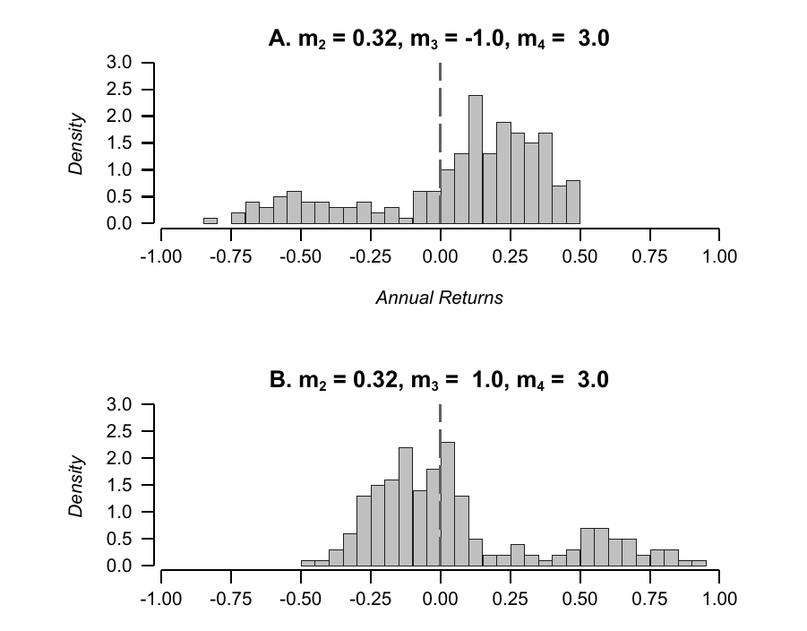

## results - skewness

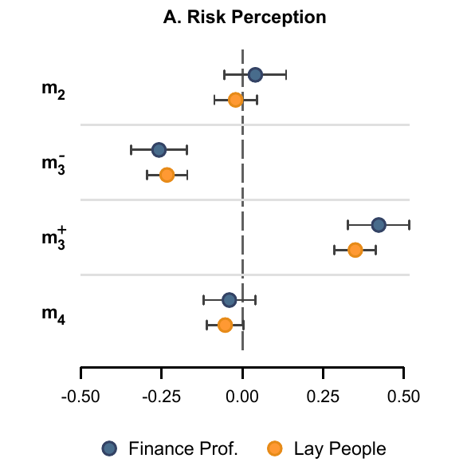

## results - aggregate risk measures

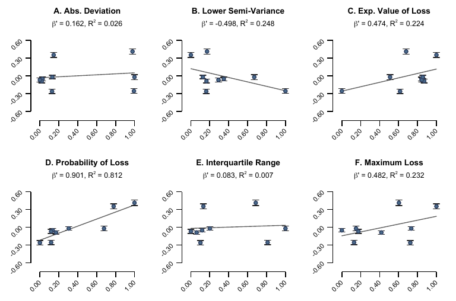

# Roads ahead

## Theory

- Spiliopoulos & Hertwig: *different* **decision rules** for different contexts
- Schneider and Sutter: **higher moments** matter
- Sunder et al: *curvature of utility* function **not** a valid theory
- **Ergodicity** economics (peters et al): drop EV, use time-means
- …

## Empirics

- use **meta-analysis** to find patterns
  - do not aggregate *by task* but **by characteristic**
  - map what correlates and what doesn’t
- tackle **noise** through
  - binary chocies among lotteries
  - econometric modeling of noise
  - individual esitmates with MaxLik
  - iterate with Machine Learning to fid best lottery set
- tackle **perception** rather than assuming it away

## In a few words…

- *“…future research must carefully consider the problem of adequately **defining** and **assessing** risk taking behavior.”*
- **exactly as in 1962**

# Thanks!

## Contribute to the meta-analysis!

**if**:

- you have **run a RET**
- you have run **more** than one
- you have run a RET and a **questionnaire**
- you have run a RET and another **risk-related measure**

> send your data – paolo.crosetto@inra.fr

> github: (https://github.com/paolocrosetto/METARET)

> shiny app: (https://paolocrosetto.shinyapps.io/METARET/)